# Title: Predictors of land-surface temperature and air pollution across Canadian cities are largely scale and city dependent

Authors

Isabella C Richmond

Department of Biology, Concordia University

Nicole Yu

Department of Biology, Concordia University

Alec L Robitaille

Department of Biology, Memorial University of Newfoundland

Kayleigh Hutt-Taylor

Department of Biology, Concordia University

Dr. Carly D Ziter

Department of Biology, Concordia University

* isabella.richmond@mail.concordia.ca

# Tables

**Table S1a. Mean and standard deviations of all response variables. Scale indicates the scale of the model/data. For the model data, pixel values from satellite images across a city, neighbourhood, or street area were averaged. For this table, the values for each neighbourhood or street in a city were then summarized at the city scale, taking the average and standard deviation. There are no air pollutant measurements at the street scale, as the data is too coarse. Temperature measurements are in degrees Celsius and air pollutant measurements are in mol/m2.**

| City | Scale | Mean Temperature | Std Dev Temperature | Mean CO | Std Dev CO | Mean NO2 | Std Dev NO2 | Mean O3 | Std Dev O3 | Mean UV | Std Dev UV |
| --- | --- | --- | --- | --- | --- | --- | --- | --- | --- | --- | --- |
| Calgary | City | 34 | 3.70 | 0.033 | 0.0100 | 2.9e-05 | 9.0e-06 | 0.15 | NA | -0.24 | 0.69 |
| Halifax | City | 24 | 4.40 | 0.038 | 0.0070 | 1.7e-05 | 6.4e-06 | 0.15 | NA | -0.69 | 0.51 |
| Montreal | City | 32 | 2.40 | 0.039 | 0.0082 | 4.1e-05 | 2.0e-05 | 0.15 | NA | -0.39 | 0.65 |
| Ottawa | City | 28 | 0.79 | 0.039 | 0.0079 | 1.8e-05 | 8.5e-06 | 0.15 | NA | -0.61 | 0.58 |
| Toronto | City | 35 | 2.40 | 0.038 | 0.0066 | 5.8e-05 | 2.7e-05 | 0.15 | NA | -0.54 | 0.59 |
| Vancouver | City | 31 | 4.50 | 0.034 | 0.0076 | 5.5e-05 | 2.3e-05 | 0.15 | NA | -0.38 | 0.73 |
| Winnipeg | City | 30 | 2.20 | 0.040 | 0.0120 | 1.8e-05 | 6.5e-06 | 0.15 | NA | -0.31 | 0.75 |
| Calgary | Neighbourhood | 35 | 1.70 | 0.033 | 0.0098 | 3.1e-05 | 1.5e-05 | 0.15 | 0.0120 | -0.19 | 0.74 |
| Halifax | Neighbourhood | 26 | 0.53 | 0.038 | 0.0075 | 1.9e-05 | 9.3e-06 | 0.15 | 0.0100 | -0.65 | 0.62 |
| Montreal | Neighbourhood | 32 | 0.17 | 0.040 | 0.0084 | 3.9e-05 | 2.3e-05 | 0.15 | 0.0120 | -0.38 | 0.67 |
| Ottawa | Neighbourhood | 30 | 2.00 | 0.039 | 0.0078 | 2.0e-05 | 1.1e-05 | 0.15 | 0.0091 | -0.55 | 0.66 |
| Toronto | Neighbourhood | 34 | 0.78 | 0.039 | 0.0070 | 5.8e-05 | 3.2e-05 | 0.15 | 0.0095 | -0.55 | 0.66 |
| Vancouver | Neighbourhood | 32 | 0.79 | 0.034 | 0.0078 | 5.5e-05 | 2.6e-05 | 0.15 | 0.0110 | -0.37 | 0.76 |
| Winnipeg | Neighbourhood | 31 | 1.30 | 0.040 | 0.0130 | 2.0e-05 | 8.8e-06 | 0.15 | 0.0130 | -0.24 | 0.78 |
| Calgary | Street | 34 | 3.80 | NA | NA | NA | NA | NA | NA | NA | NA |
| Halifax | Street | 32 | 1.30 | NA | NA | NA | NA | NA | NA | NA | NA |
| Montreal | Street | 32 | 1.90 | NA | NA | NA | NA | NA | NA | NA | NA |
| Ottawa | Street | 32 | 3.00 | NA | NA | NA | NA | NA | NA | NA | NA |
| Toronto | Street | 35 | 2.10 | NA | NA | NA | NA | NA | NA | NA | NA |
| Vancouver | Street | 32 | 3.50 | NA | NA | NA | NA | NA | NA | NA | NA |
| Winnipeg | Street | 31 | 3.10 | NA | NA | NA | NA | NA | NA | NA | NA |

**Table S1b. Mean and standard deviations of all explanatory variables. Scale indicates the scale of the model/data. For the model data,values across the city, neighbourhood, or street area were averaged. For this table, the values for each neighbourhood or street in a city were then summarized at the city scale, taking the average and standard deviation.**

| City | Scale | Area (km2) | Basal Area (m2/m2) | Stem Density (ind/km2) | Species Richness | Shannon | Functional Group Richness | Functional Group Shannon | Mean DBH (cm) | Std Dev DBH (cm) | Popuation | Mean NDVI | Mean NDBI | Building Cover (buildings/km2) | Building Cover (km2/km2) | Proportion Highway | Road Density (km/km2) | Population Density (ind/km2) | Mean Building Height (m) | Std Dev Building Height (m) | Single Detached Homes (%) | Large Apt Building (%) | Semi-Detached Home (%) | Row House (%) | Duplex Apartment (%) | Small Apt Building (%) | Moving Dwelling (%) | Median Income ($) | Recent Immigrants (%) | … |
| --- | --- | --- | --- | --- | --- | --- | --- | --- | --- | --- | --- | --- | --- | --- | --- | --- | --- | --- | --- | --- | --- | --- | --- | --- | --- | --- | --- | --- | --- | --- |
| Calgary | City | 920.0 | 2.6e-05 | 500 | 170.0 | 3.1 | 5.0 | 1.30 | 19 | 17 | 1300000 | 0.27 | -0.061 | 430 | 0.084 | 0.0710 | 8.0 | 4100 | 6.0 | 5.4 | 0.610 | 0.053 | 0.064 | 0.096 | 0.041 | 0.130 | 2.8e-03 | 42000 | 0.120 | … |
| Halifax | City | 1100.0 | 6.4e-06 | 62 | 210.0 | 3.8 | 6.0 | 1.20 | 24 | 27 | 390000 | 0.48 | -0.240 | 79 | 0.016 | 0.0670 | 2.0 | 3400 | 6.1 | 5.1 | 0.470 | 0.140 | 0.078 | 0.043 | 0.036 | 0.210 | 1.9e-02 | 38000 | 0.061 | … |
| Montreal | City | 270.0 | 7.4e-05 | 770 | 260.0 | 3.4 | 6.0 | 1.20 | 26 | 23 | 1600000 | 0.26 | -0.080 | 400 | 0.170 | 0.0430 | 13.0 | 12000 | 7.6 | 7.5 | 0.096 | 0.150 | 0.037 | 0.038 | 0.120 | 0.560 | 3.6e-04 | 35000 | 0.110 | … |
| Ottawa | City | 3000.0 | 5.4e-06 | 79 | 140.0 | 3.5 | 5.0 | 1.30 | 22 | 20 | 1000000 | 0.48 | -0.190 | 71 | 0.018 | 0.0370 | 2.4 | 4400 | 5.3 | 5.0 | 0.460 | 0.140 | 0.055 | 0.230 | 0.018 | 0.094 | 2.3e-03 | 46000 | 0.076 | … |
| Toronto | City | 670.0 | 7.8e-05 | 890 | 180.0 | 3.7 | 6.0 | 1.20 | 25 | 22 | 2900000 | 0.30 | -0.090 | 490 | 0.150 | 0.0570 | 9.7 | 14000 | 7.3 | 9.3 | 0.280 | 0.400 | 0.070 | 0.063 | 0.049 | 0.130 | 3.2e-05 | 38000 | 0.120 | … |
| Vancouver | City | 120.0 | 1.5e-04 | 1200 | 370.0 | 4.2 | 6.0 | 1.10 | 30 | 24 | 690000 | 0.30 | -0.100 | 840 | 0.160 | 0.0180 | 13.0 | 12000 | 7.6 | 9.0 | 0.180 | 0.260 | 0.016 | 0.039 | 0.220 | 0.280 | 5.0e-05 | 39000 | 0.110 | … |
| Winnipeg | City | 570.0 | 3.4e-05 | 350 | 100.0 | 2.5 | 6.0 | 1.10 | 29 | 20 | 760000 | 0.32 | -0.120 | 450 | 0.091 | 0.0490 | 6.8 | 4100 | 4.3 | 4.3 | 0.630 | 0.100 | 0.043 | 0.039 | 0.017 | 0.170 | 2.1e-03 | 36000 | 0.120 | … |
| Calgary | Neighbourhood | 1.8 | 8.2e-05 | 1100 | 47.0 | 2.6 | 4.6 | 1.20 | 22 | 17 | 4100 | 0.23 | -0.042 | 750 | 0.140 | 0.0730 | 12.0 | 3900 | 6.9 | 4.6 | 0.510 | 0.098 | 0.062 | 0.100 | 0.060 | 0.170 | 1.2e-06 | 43000 | 0.110 | … |
| Halifax | Neighbourhood | 27.0 | 7.7e-06 | 120 | 83.0 | 3.2 | 4.9 | 1.10 | 16 | 16 | 20000 | 0.39 | -0.180 | 140 | 0.025 | 0.0490 | 3.2 | 1300 | 4.9 | 3.3 | 0.620 | 0.050 | 0.120 | 0.020 | 0.022 | 0.100 | 5.9e-02 | 39000 | 0.031 | … |
| Montreal | Neighbourhood | 22.0 | 7.4e-05 | 860 | 130.0 | 3.2 | 5.7 | 1.10 | 25 | 21 | 110000 | 0.22 | -0.068 | 330 | 0.180 | 0.0500 | 13.0 | 12000 | 8.1 | 6.7 | 0.099 | 0.140 | 0.020 | 0.036 | 0.110 | 0.580 | 3.5e-04 | 35000 | 0.100 | … |
| Ottawa | Neighbourhood | 27.0 | 4.3e-05 | 510 | 63.0 | 3.1 | 4.9 | 1.20 | 23 | 18 | 8800 | 0.37 | -0.140 | 440 | 0.110 | 0.0350 | 9.2 | 4100 | 5.1 | 4.1 | 0.470 | 0.160 | 0.053 | 0.220 | 0.016 | 0.086 | 2.4e-03 | 45000 | 0.073 | … |
| Toronto | Neighbourhood | 4.1 | 1.0e-04 | 1100 | 93.0 | 3.4 | 5.9 | 1.10 | 25 | 22 | 17000 | 0.28 | -0.085 | 560 | 0.180 | 0.0460 | 11.0 | 14000 | 8.7 | 8.4 | 0.290 | 0.370 | 0.082 | 0.059 | 0.049 | 0.150 | 1.8e-05 | 40000 | 0.110 | … |
| Vancouver | Neighbourhood | 5.6 | 1.4e-04 | 1200 | 180.0 | 4.0 | 5.6 | 1.10 | 31 | 23 | 29000 | 0.23 | -0.056 | 890 | 0.160 | 0.0032 | 13.0 | 8100 | 6.6 | 3.8 | 0.210 | 0.100 | 0.023 | 0.059 | 0.250 | 0.340 | 0.0e+00 | 37000 | 0.095 | … |
| Winnipeg | Neighbourhood | 1.7 | 7.5e-05 | 700 | 29.0 | 2.0 | 4.6 | 1.00 | 27 | 16 | 3200 | 0.25 | -0.067 | 780 | 0.140 | 0.0600 | 11.0 | 3400 | 5.4 | 3.9 | 0.600 | 0.130 | 0.045 | 0.046 | 0.017 | 0.160 | 2.1e-03 | 37000 | 0.110 | … |
| Calgary | Street | NA | 1.7e-04 | 2700 | 6.6 | 1.4 | 3.1 | 0.87 | 22 | 14 | 30 | 0.20 | -0.034 | 1100 | 0.150 | NA | NA | 3600 | 5.3 | 2.5 | 0.640 | 0.032 | 0.070 | 0.075 | 0.059 | 0.120 | 3.3e-05 | 44000 | 0.095 | … |
| Halifax | Street | NA | 2.2e-04 | 1700 | 6.5 | 1.5 | 2.7 | 0.76 | 26 | 18 | 24 | 0.31 | -0.110 | 850 | 0.110 | NA | NA | 3200 | 5.5 | 3.0 | 0.510 | 0.088 | 0.093 | 0.045 | 0.057 | 0.200 | 5.7e-03 | 39000 | 0.047 | … |
| Montreal | Street | NA | 1.9e-04 | 2100 | 7.6 | 1.6 | 2.9 | 0.80 | 26 | 17 | 77 | 0.22 | -0.061 | 650 | 0.190 | NA | NA | 10000 | 6.9 | 3.1 | 0.140 | 0.094 | 0.051 | 0.038 | 0.120 | 0.560 | 2.3e-04 | 35000 | 0.098 | … |
| Ottawa | Street | NA | 1.5e-04 | 1900 | 7.3 | 1.6 | 3.0 | 0.88 | 24 | 15 | 30 | 0.30 | -0.099 | 840 | 0.160 | NA | NA | 3900 | 4.8 | 2.5 | 0.550 | 0.069 | 0.070 | 0.190 | 0.021 | 0.093 | 1.1e-03 | 47000 | 0.058 | … |
| Toronto | Street | NA | 2.3e-04 | 2200 | 9.8 | 1.8 | 3.2 | 0.84 | 28 | 20 | 50 | 0.25 | -0.073 | 810 | 0.150 | NA | NA | 7400 | 6.3 | 3.4 | 0.450 | 0.140 | 0.110 | 0.057 | 0.074 | 0.170 | 0.0e+00 | 41000 | 0.082 | … |
| Vancouver | Street | NA | 3.1e-04 | 2800 | 7.7 | 1.6 | 2.8 | 0.69 | 30 | 19 | 55 | 0.26 | -0.073 | 810 | 0.110 | NA | NA | 7300 | 6.4 | 3.1 | 0.290 | 0.088 | 0.022 | 0.036 | 0.300 | 0.270 | 8.9e-05 | 38000 | 0.093 | … |
| Winnipeg | Street | NA | 1.9e-04 | 2000 | 4.9 | 1.0 | 2.6 | 0.60 | 29 | 13 | 28 | 0.25 | -0.063 | 910 | 0.130 | NA | NA | 3200 | 4.2 | 2.4 | 0.740 | 0.052 | 0.043 | 0.037 | 0.013 | 0.120 | 2.5e-03 | 39000 | 0.091 | … |

**Table S2. Data sources used in the study.**

| Dataset | Area/Link | Data Type |
| --- | --- | --- |
| Neighbourhood | [Halifax](https://data-hrm.hub.arcgis.com/datasets/b4088a068b794436bdb4e5c31df76fe2_0/explore) [Montreal](https://donnees.montreal.ca/dataset/9797a946-9da8-41ec-8815-f6b276dec7e9/resource/e8bea324-044… | Shapefile/CSV |
| Parks | [Halifax](https://data-hrm.hub.arcgis.com/datasets/3df29a3d088a42d890f11d027ea1c0be_0/explore) [Montreal](https://donnees.montreal.ca/fr/dataset/grands-parcs-parcs-d-arrondissements-et-espaces-publics… | Shapefile/CSV |
| Street Trees | [Halifax](https://data-hrm.hub.arcgis.com/datasets/33a4e9b6c7e9439abcd2b20ac50c5a4d_0/explore) [Montreal](https://donnees.montreal.ca/fr/dataset/arbres) [Ottawa](https://open.ottawa.ca/datasets/ottawa… |  |
| Census Metropolitan Areas | National | Shapefile |
| Roads | [National](https://www12.statcan.gc.ca/census-recensement/2011/geo/RNF-FRR/index-s-eng.cfm?year=24) | Shapefile |
| Dissemination Areas | National | Shapefile |
| 2021 Census | [National](https://www12.statcan.gc.ca/census-recensement/2021/dp-pd/prof/details/download-telecharger.cfm?Lang=E) | CSV |
| Buildings | [National](https://github.com/microsoft/CanadianBuildingFootprints) | Shapefile |
| NDVI/NDBI | [International - Sentinel 2](https://developers.google.com/earth-engine/datasets/catalog/sentinel-2) (5 day revisit frequency) | TIFF |
| Land Surface Temperature | [International - Landsat 8](https://developers.google.com/earth-engine/datasets/catalog/landsat-8/) (2 week revisit frequency) | TIFF |
| Air Pollutants | [International - Sentinel 5p TROPOMI](https://developers.google.com/earth-engine/datasets/catalog/sentinel-5p) (2 day revisit frequency) | TIFF |

**Table S3. Model Performance Metrics. For each model, the root mean squared error (rmse), R2 (rsq), and mean absolute error (mae) were calculated for the testing and training datasets. A well fitted model should not have large differences in error metric values between the training and testing dataset.**

| Model | Scale | Dataset | Metric | Value |
| --- | --- | --- | --- | --- |
| CO | City | test | rmse | 6.4e-03 |
| CO | City | train | rmse | 5.4e-03 |
| CO | City | test | rsq | 5.2e-01 |
| CO | City | train | rsq | 6.7e-01 |
| CO | City | test | mae | 4.3e-03 |
| CO | City | train | mae | 3.7e-03 |
| NO2 | City | test | rmse | 1.7e-05 |
| NO2 | City | train | rmse | 1.4e-05 |
| NO2 | City | test | rsq | 5.3e-01 |
| NO2 | City | train | rsq | 5.5e-01 |
| NO2 | City | test | mae | 1.1e-05 |
| NO2 | City | train | mae | 1.0e-05 |
| O3 | City | test | rmse | 9.5e-03 |
| O3 | City | train | rmse | 8.0e-03 |
| O3 | City | test | rsq | 4.2e-01 |
| O3 | City | train | rsq | 5.5e-01 |
| O3 | City | test | mae | 7.2e-03 |
| O3 | City | train | mae | 6.1e-03 |
| SO2 | City | test | rmse | 3.1e-04 |
| SO2 | City | train | rmse | 3.5e-04 |
| SO2 | City | test | rsq | 2.8e-02 |
| SO2 | City | train | rsq | 6.6e-02 |
| SO2 | City | test | mae | 2.3e-04 |
| SO2 | City | train | mae | 2.2e-04 |
| Temperature | City | test | rmse | 2.3e+00 |
| Temperature | City | train | rmse | 3.1e+00 |
| Temperature | City | test | rsq | 4.0e-01 |
| Temperature | City | train | rsq | 5.3e-01 |
| Temperature | City | test | mae | 1.8e+00 |
| Temperature | City | train | mae | 2.6e+00 |
| UV | City | test | rmse | 6.8e-01 |
| UV | City | train | rmse | 6.0e-01 |
| UV | City | test | rsq | 8.2e-02 |
| UV | City | train | rsq | 1.6e-01 |
| UV | City | test | mae | 5.3e-01 |
| UV | City | train | mae | 4.8e-01 |
| CO | Neighbourhood | test | rmse | 6.8e-03 |
| CO | Neighbourhood | train | rmse | 6.6e-03 |
| CO | Neighbourhood | test | rsq | 6.1e-01 |
| CO | Neighbourhood | train | rsq | 6.4e-01 |
| CO | Neighbourhood | test | mae | 4.7e-03 |
| CO | Neighbourhood | train | mae | 4.6e-03 |
| NO2 | Neighbourhood | test | rmse | 1.6e-05 |
| NO2 | Neighbourhood | train | rmse | 1.6e-05 |
| NO2 | Neighbourhood | test | rsq | 4.2e-01 |
| NO2 | Neighbourhood | train | rsq | 4.4e-01 |
| NO2 | Neighbourhood | test | mae | 1.1e-05 |
| NO2 | Neighbourhood | train | mae | 1.1e-05 |
| O3 | Neighbourhood | test | rmse | 9.2e-03 |
| O3 | Neighbourhood | train | rmse | 8.9e-03 |
| O3 | Neighbourhood | test | rsq | 4.3e-01 |
| O3 | Neighbourhood | train | rsq | 4.7e-01 |
| O3 | Neighbourhood | test | mae | 7.3e-03 |
| O3 | Neighbourhood | train | mae | 7.1e-03 |
| SO2 | Neighbourhood | test | rmse | 5.4e-04 |
| SO2 | Neighbourhood | train | rmse | 5.1e-04 |
| SO2 | Neighbourhood | test | rsq | 6.3e-02 |
| SO2 | Neighbourhood | train | rsq | 1.8e-01 |
| SO2 | Neighbourhood | test | mae | 3.9e-04 |
| SO2 | Neighbourhood | train | mae | 3.7e-04 |
| Temperature | Neighbourhood | test | rmse | 3.5e+00 |
| Temperature | Neighbourhood | train | rmse | 3.4e+00 |
| Temperature | Neighbourhood | test | rsq | 4.6e-01 |
| Temperature | Neighbourhood | train | rsq | 5.1e-01 |
| Temperature | Neighbourhood | test | mae | 2.6e+00 |
| Temperature | Neighbourhood | train | mae | 2.5e+00 |
| UV | Neighbourhood | test | rmse | 6.1e-01 |
| UV | Neighbourhood | train | rmse | 6.0e-01 |
| UV | Neighbourhood | test | rsq | 3.3e-01 |
| UV | Neighbourhood | train | rsq | 3.8e-01 |
| UV | Neighbourhood | test | mae | 4.9e-01 |
| UV | Neighbourhood | train | mae | 4.8e-01 |
| Temperature | Street | test | rmse | 4.0e+00 |
| Temperature | Street | train | rmse | 3.4e+00 |
| Temperature | Street | test | rsq | 3.7e-01 |
| Temperature | Street | train | rsq | 6.3e-01 |
| Temperature | Street | test | mae | 2.8e+00 |
| Temperature | Street | train | mae | 2.4e+00 |

# Figures

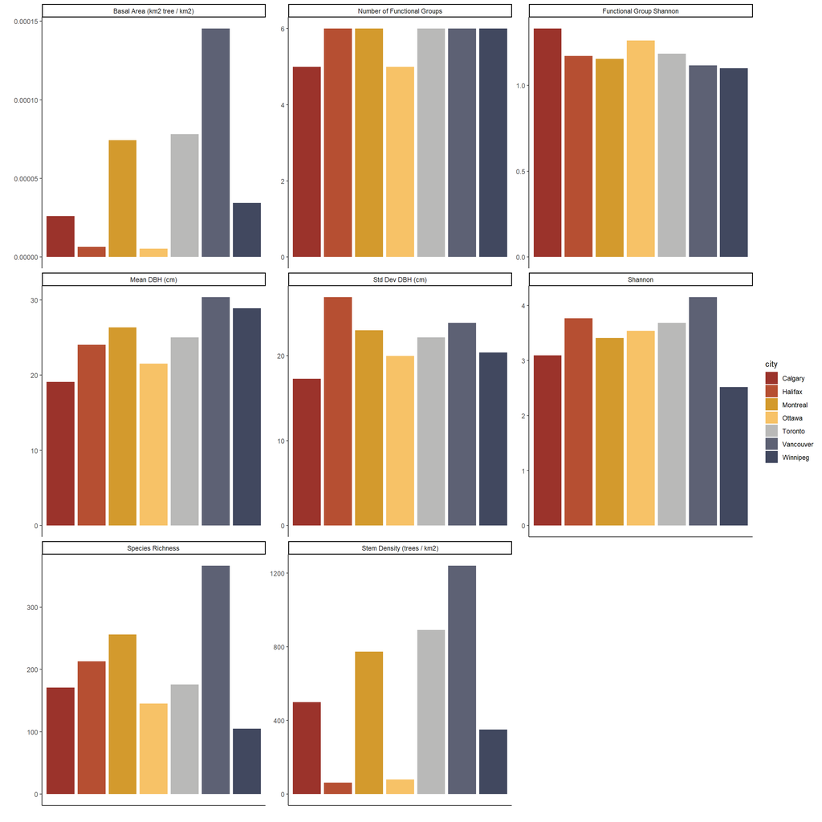

Figure A3.1a. Plot depicting the values for ecological form variables for each city at the city scale.

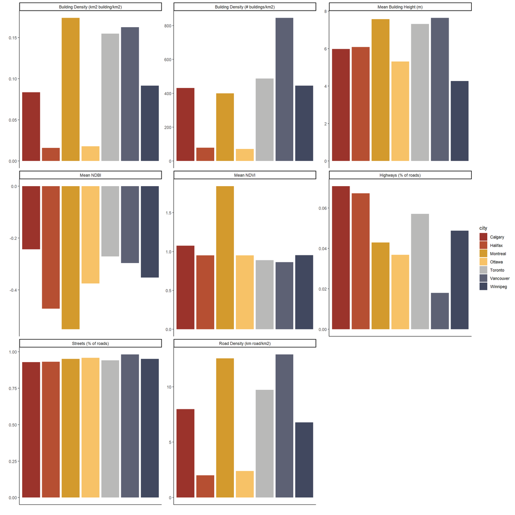

Figure A3.1b. Plot depicting the values for urban form variables for each city at the city scale.

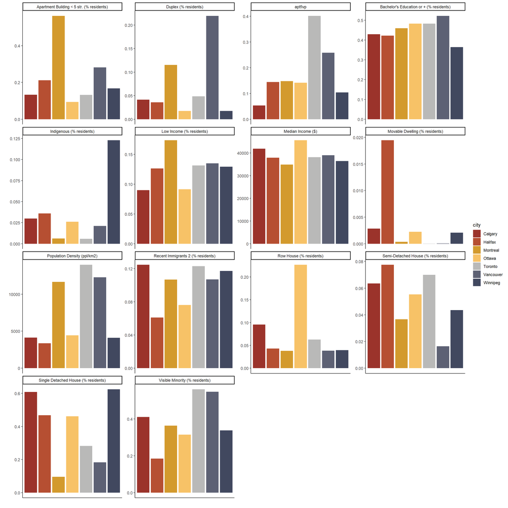

Figure A3.1c. Plot depicting the values for sociodemographic variables for each city at the city scale.

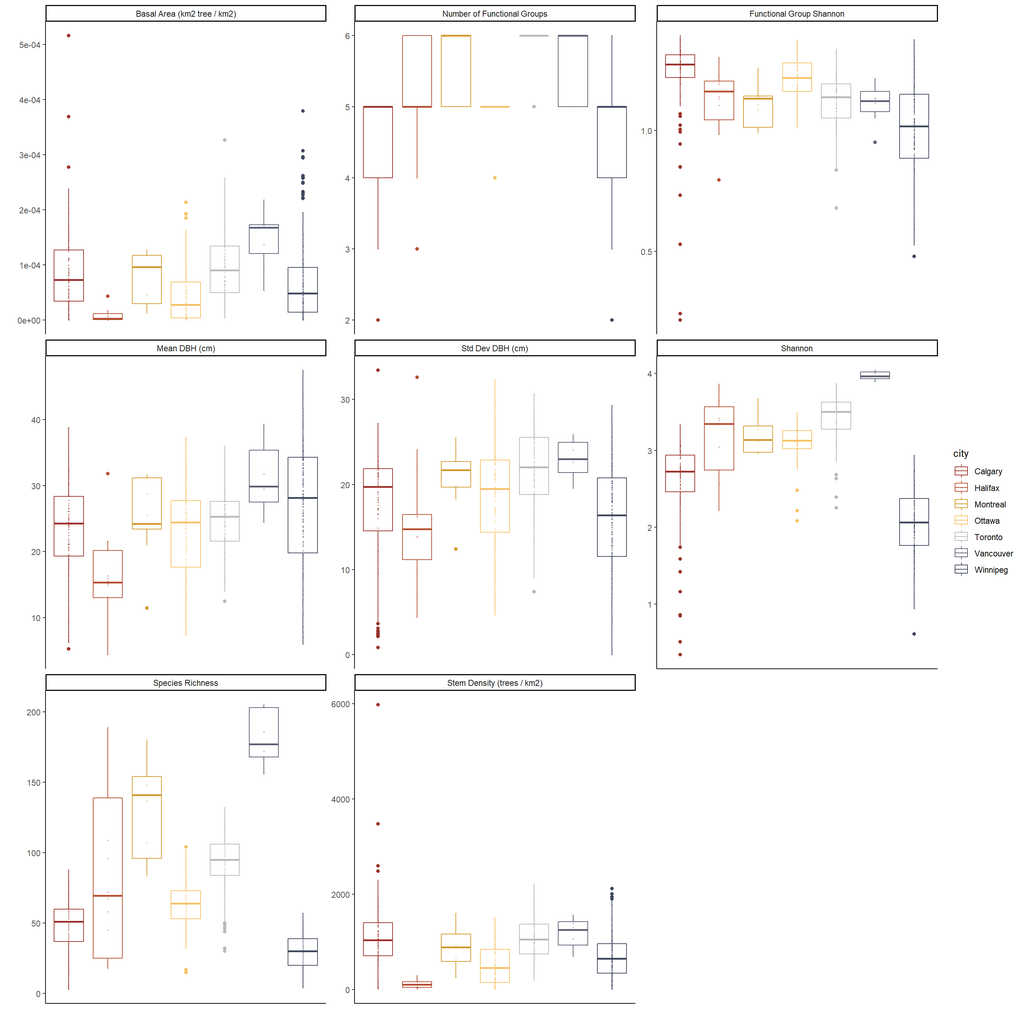

Figure A3.1d. Plot depicting the values for ecological form variables for each city at the neighbourhood scale.

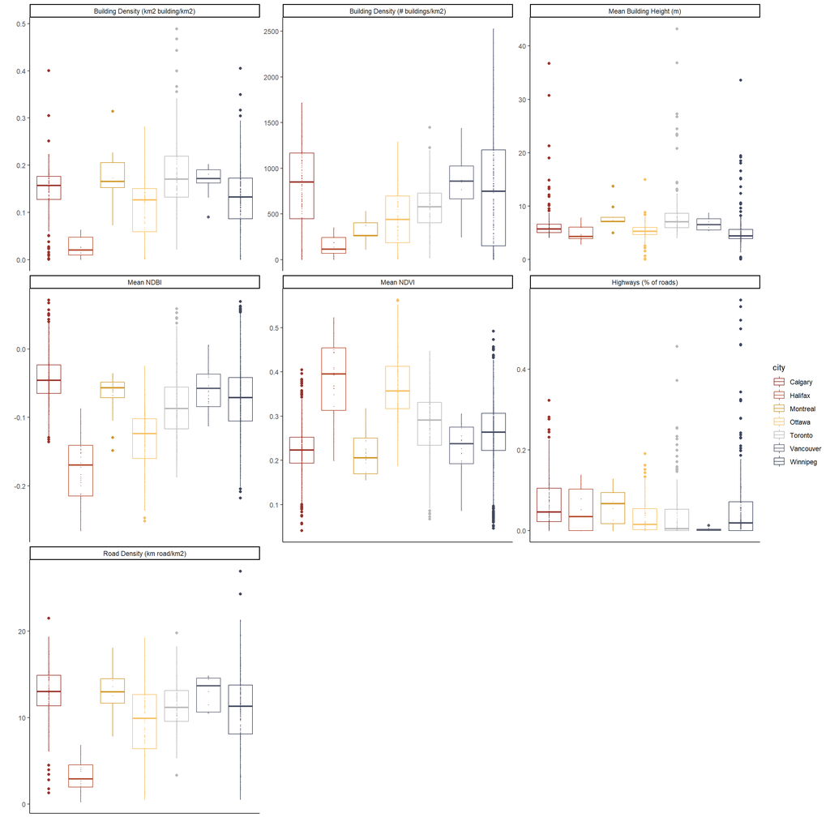

Figure A3.1e. Plot depicting the values for urban form variables for each city at the neighbourhood scale.

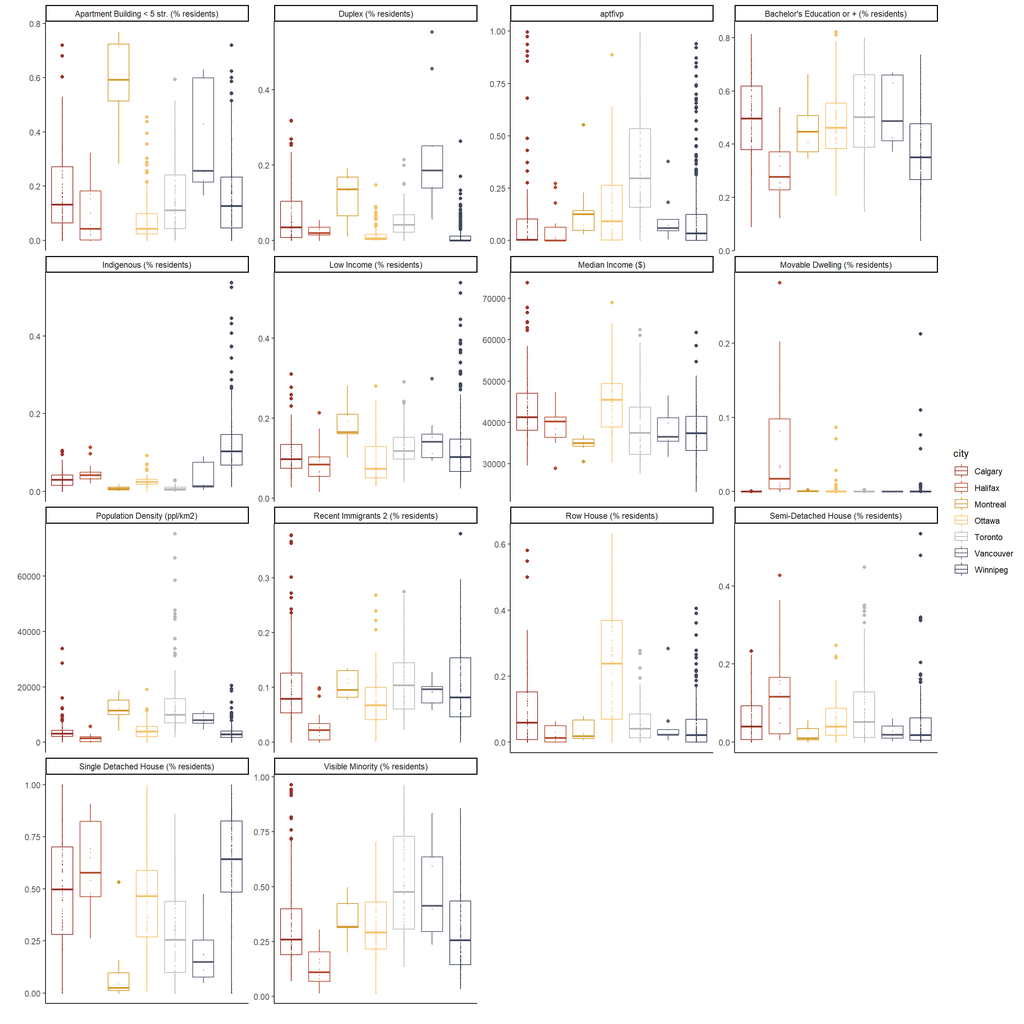

Figure A3.1f. Plot depicting the values for sociodemographic variables for each city at the neighbourhood scale.

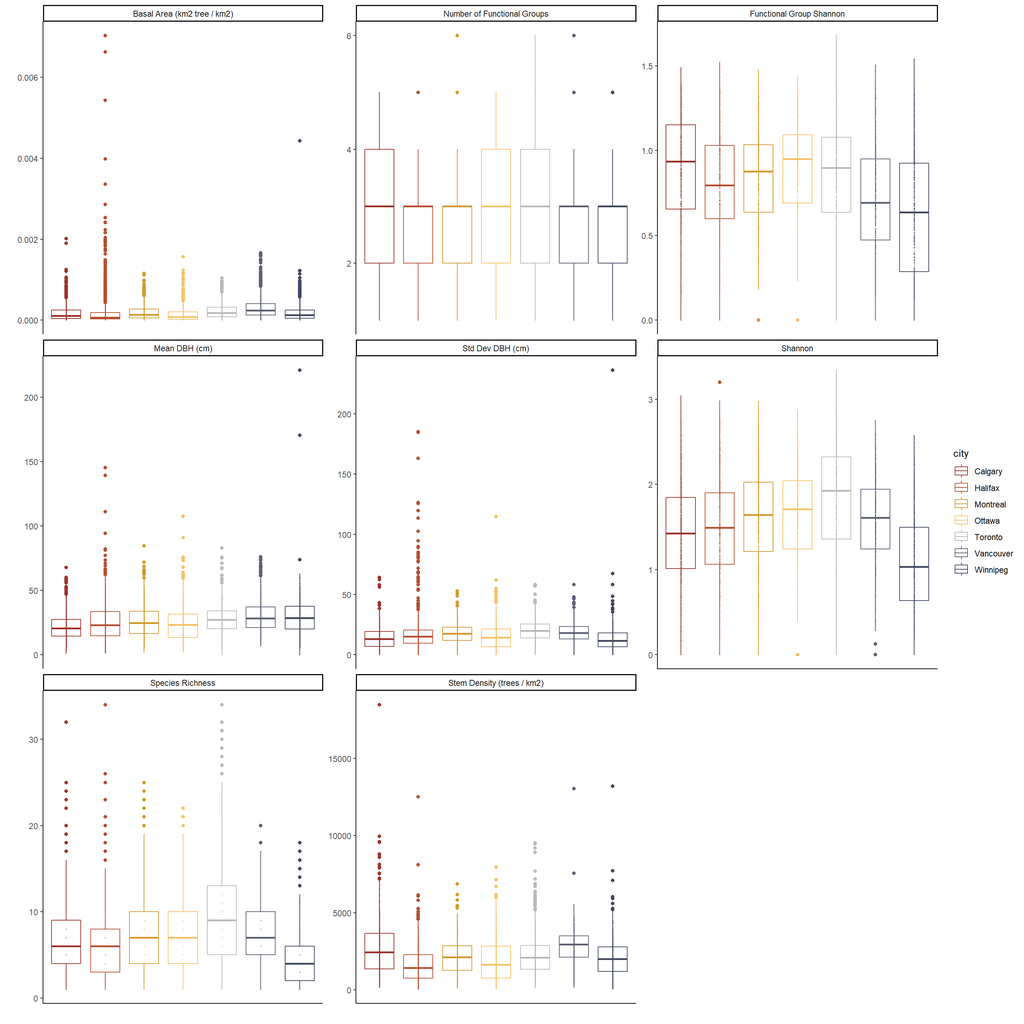

Figure A3.1h. Plot depicting the values for ecological form variables for each city at the street scale.

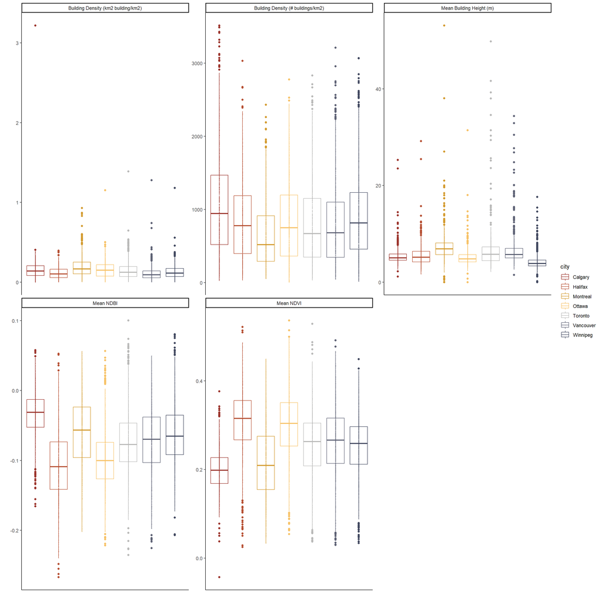

Figure A3.1h. Plot depicting the values for urban form variables for each city at the street scale.

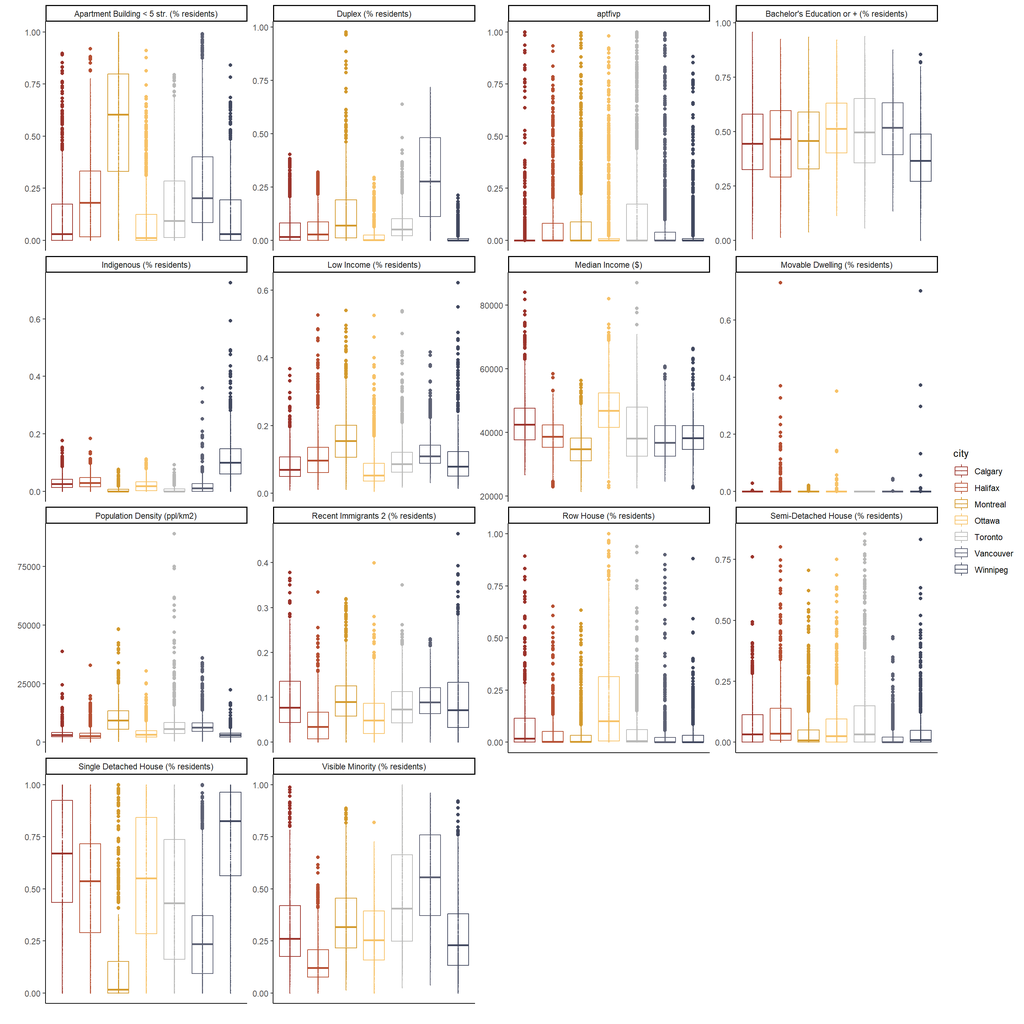

Figure A3.1i. Plot depicting the values for sociodemographic variables for each city at the street scale.

[figure not shown]

Figure A3.2. Example of satellite image coverage of Toronto neighbourhoods. Depicted is a single satellite image, with cloudy pixels removed. To be included in our analysis, satellite images had to cover an estimated 50% or more of the area of a city or neighbourhood, or 100% of a street area.

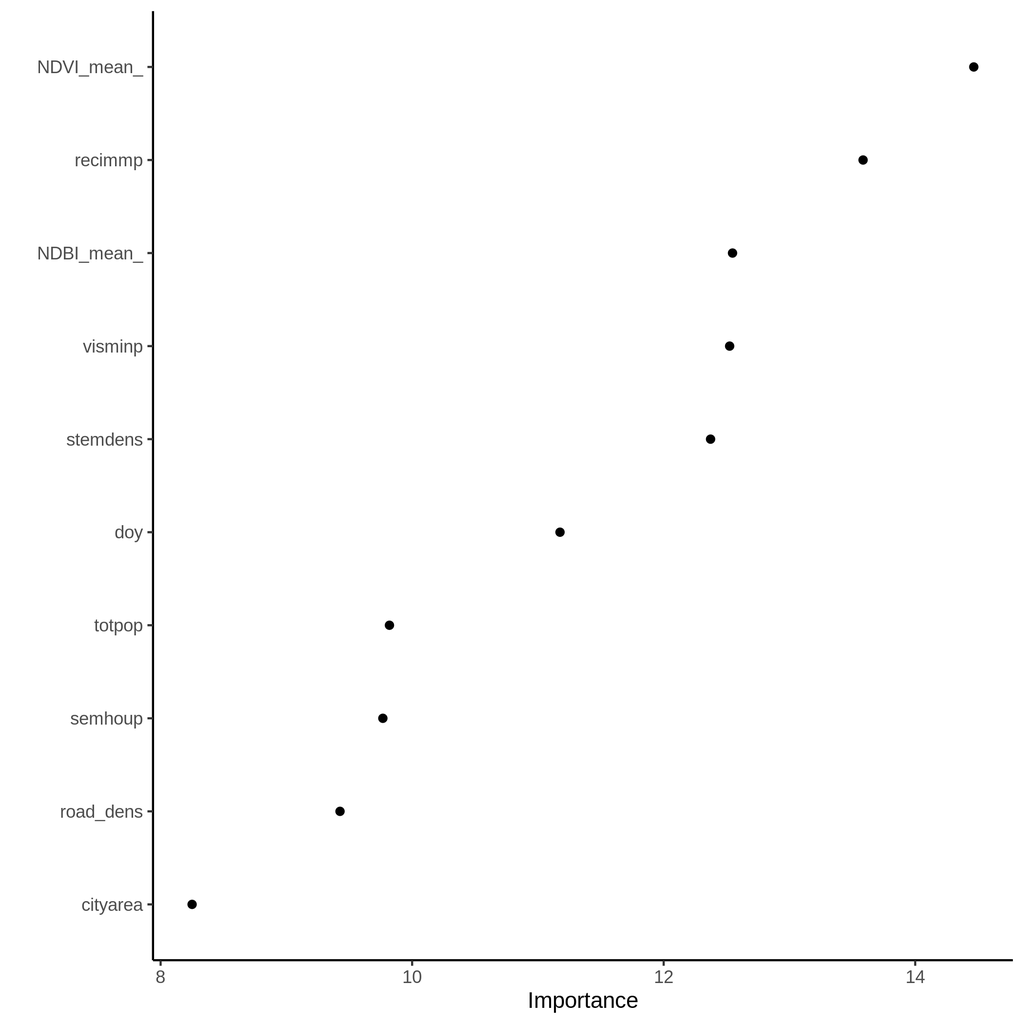

**Figure A3.3a. Variable importance plot for temperature model at the city scale.**

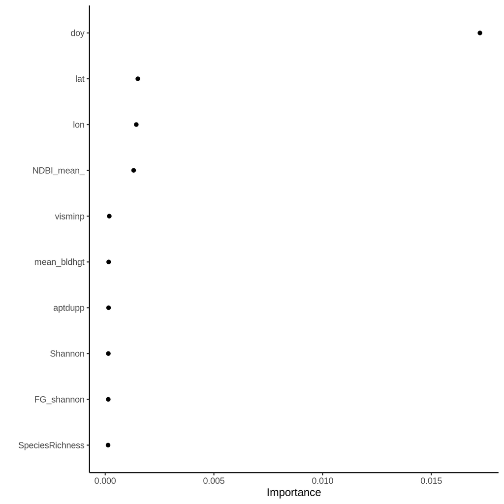

**Figure A3.3b. Variable importance plot for carbon monoxide model at the city scale.**

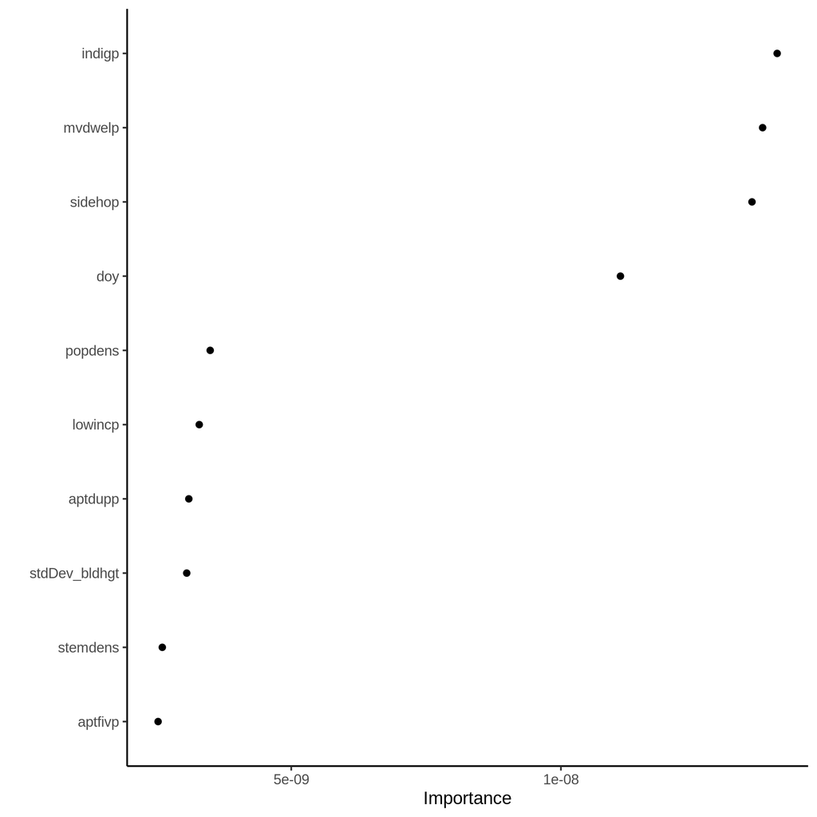

**Figure A3.3c. Variable importance plot for nitrogen dioxide model at the city scale.**

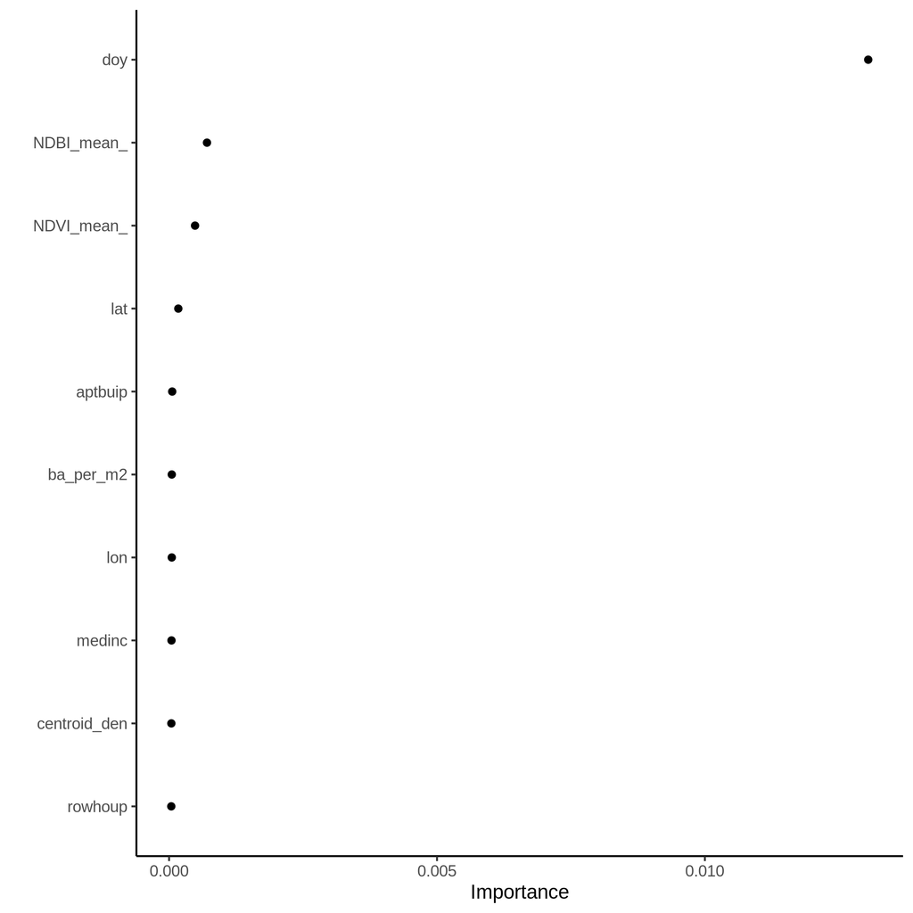

**Figure A3.3d. Variable importance plot for ozone model at the city scale.**

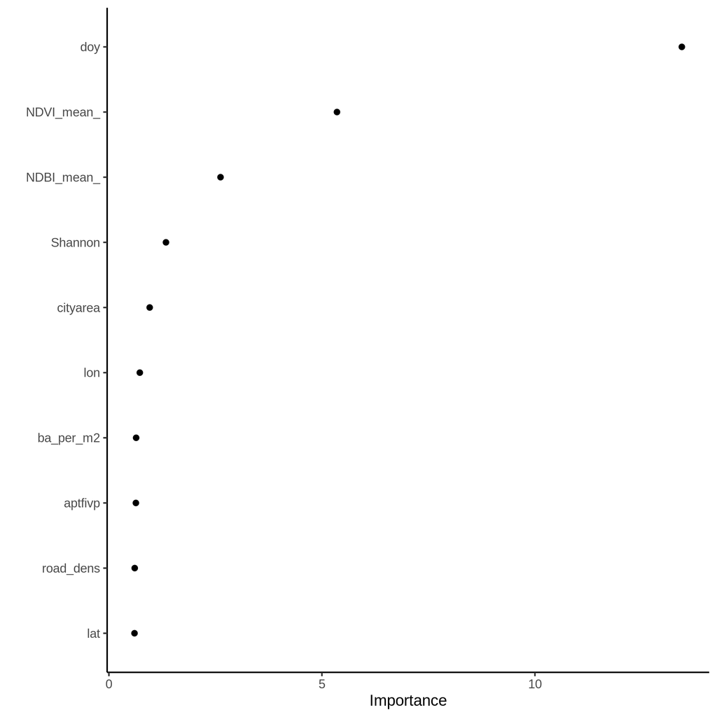

**Figure A3.3e. Variable importance plot for UV aerosols model at the city scale.**

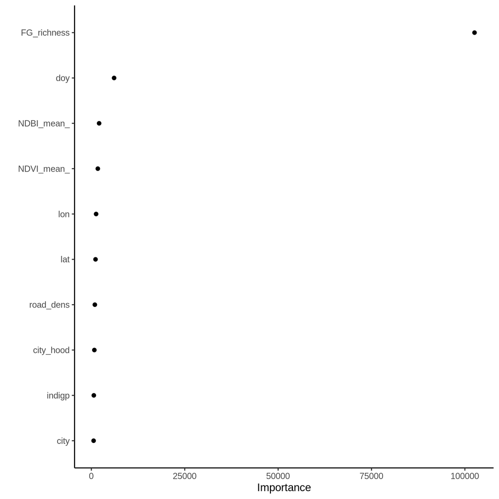

**Figure A3.3f. Variable importance plot for temperature model at the neighbourhood scale.**

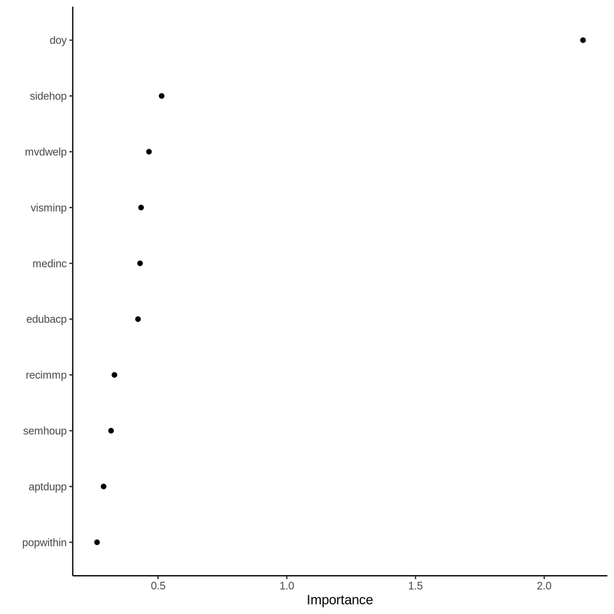

**Figure A3.3g. Variable importance plot for carbon monoxide model at the neighbourhood scale.**

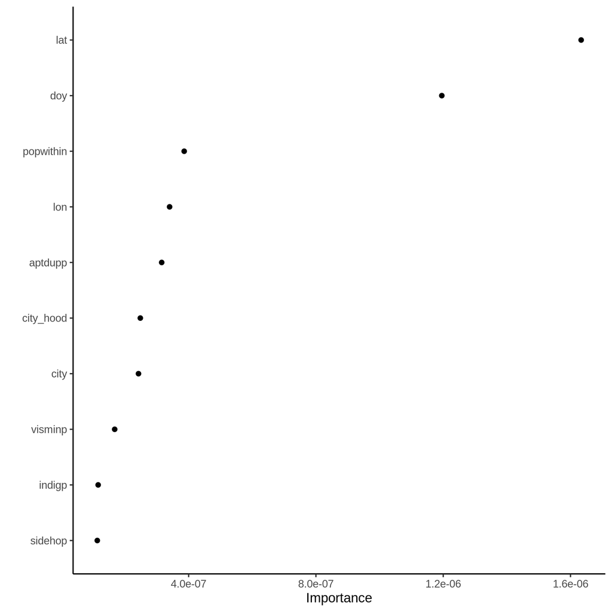

**Figure A3.3h. Variable importance plot for nitrogen dioxide model at the neighbourhood scale.**

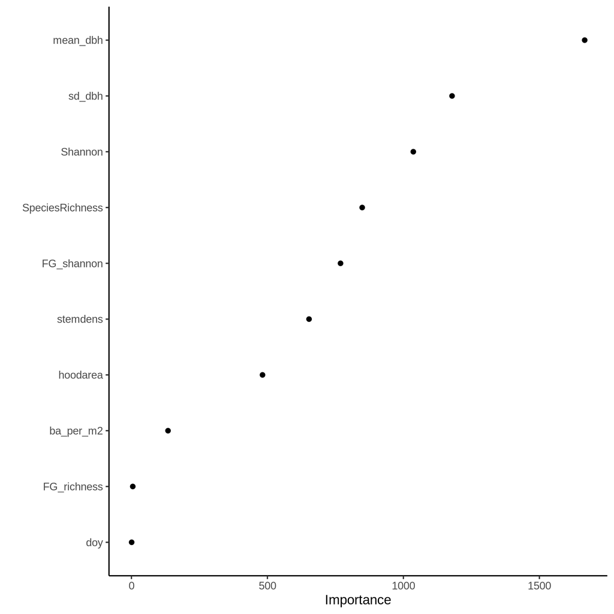

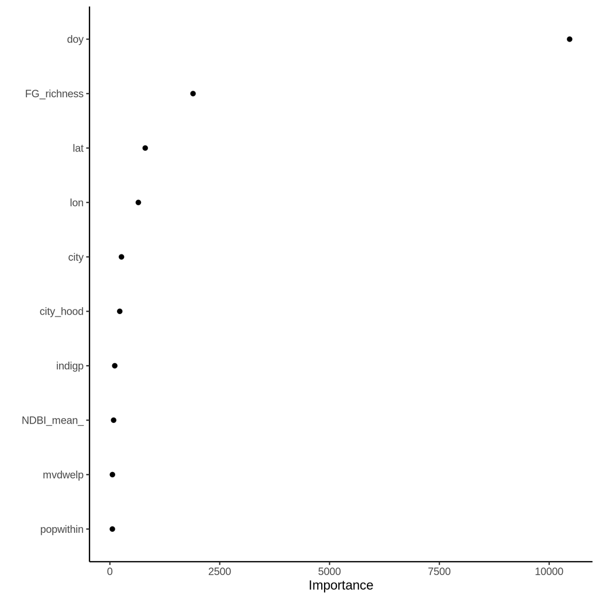

**Figure A3.3j. Variable importance plot for UV aerosols model at the neighbourhood scale.**

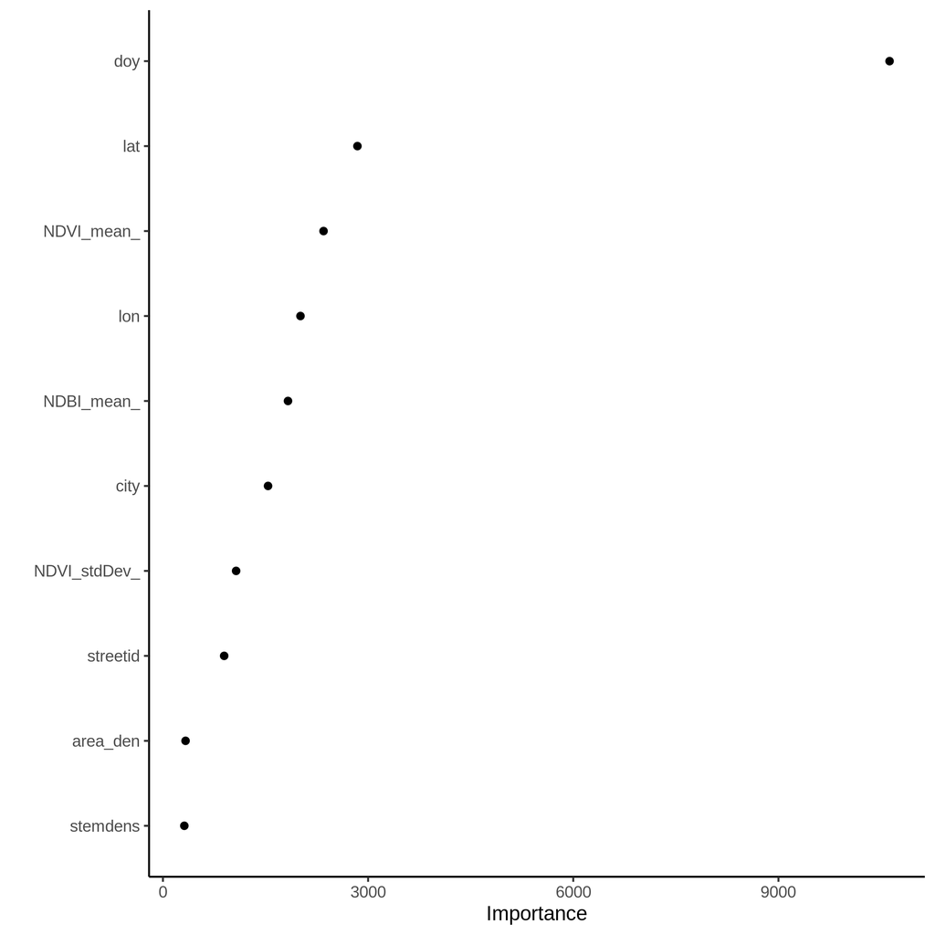

**Figure A3.3k. Variable importance plot for temperature model at the street scale.**

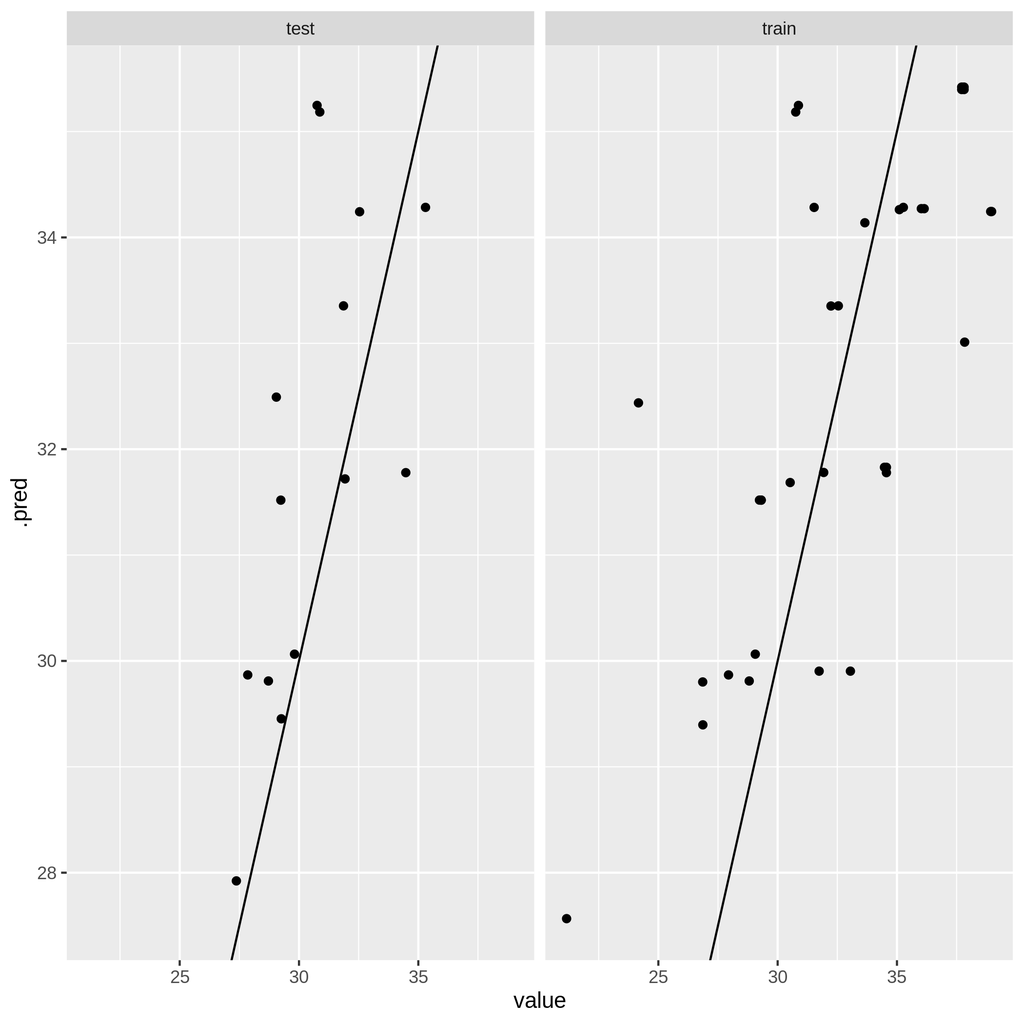

**Figure A3.4a. Model performance plot for temperature model at the city scale.**

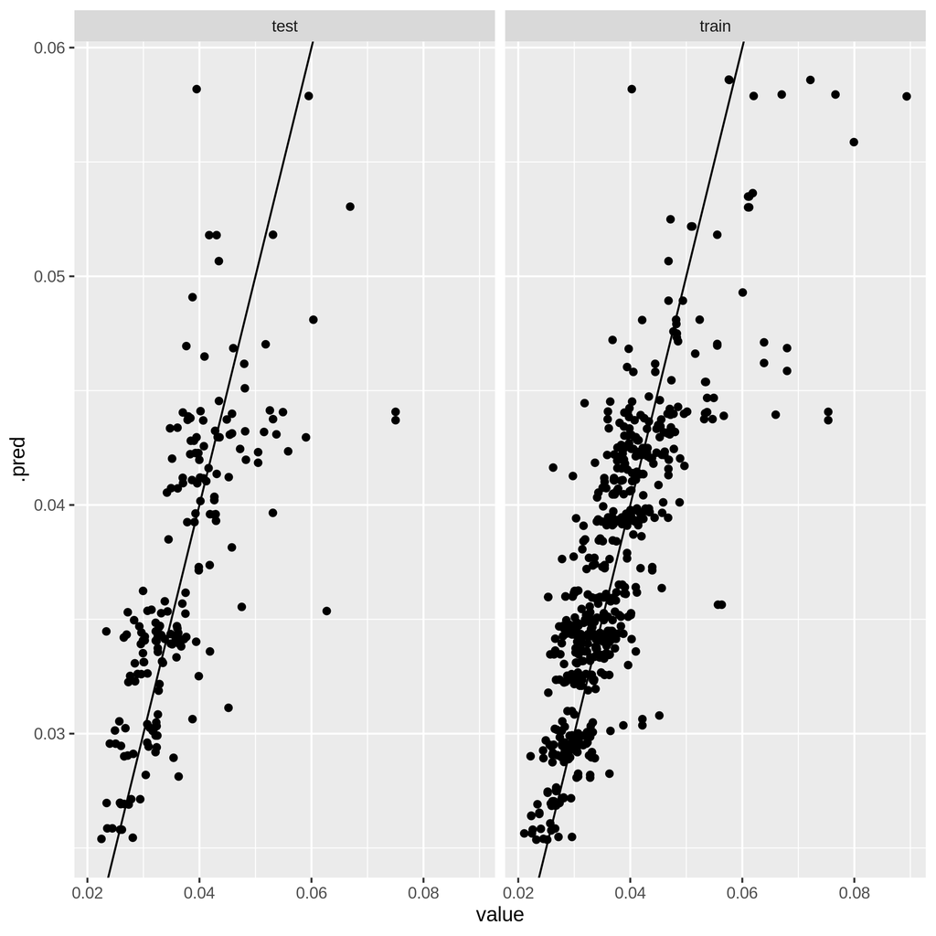

**Figure A3.4b. Model performance plot for carbon monoxide model at the city scale.**

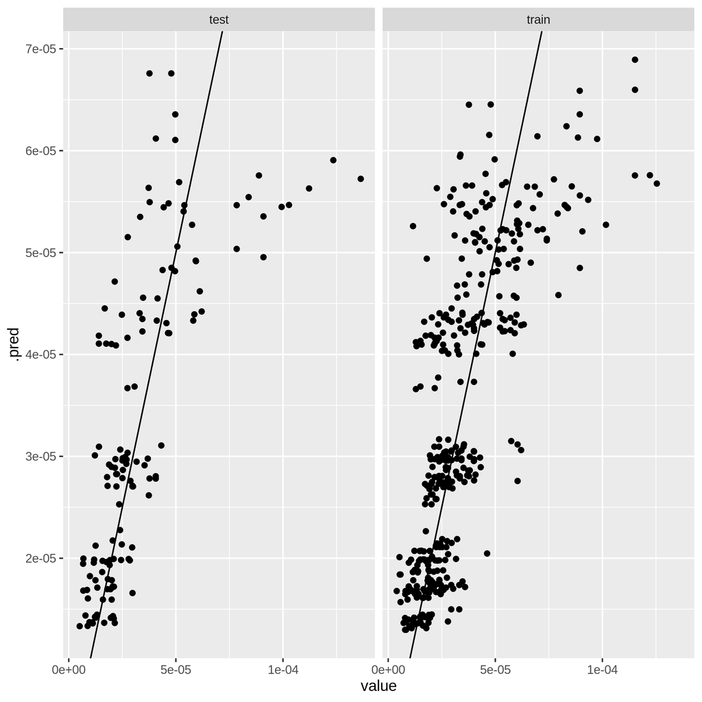

**Figure A3.4c. Model performance plot for nitrogen dioxide model at the city scale.**

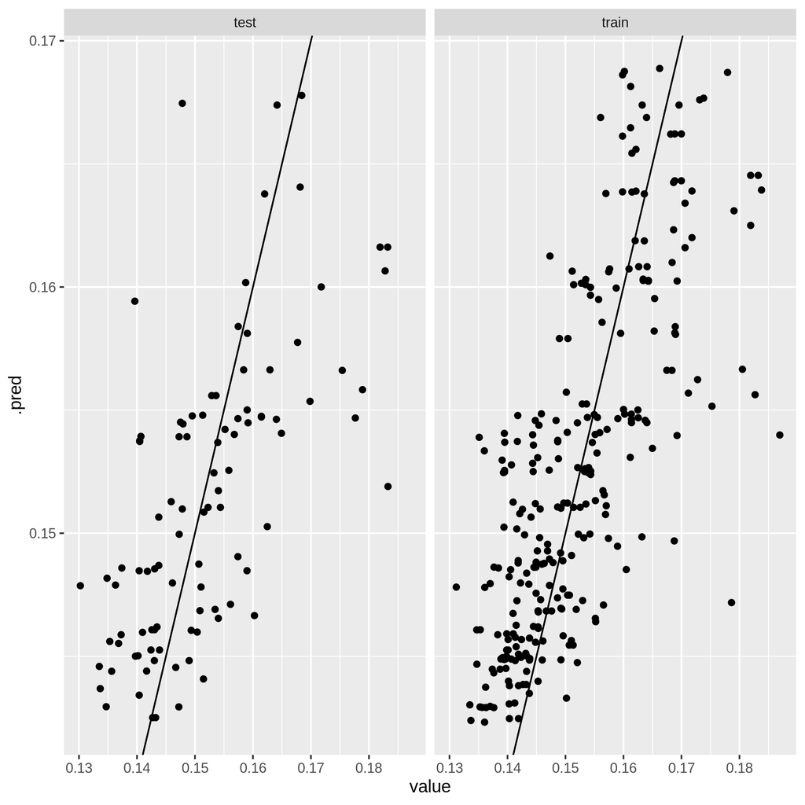

**Figure A3.4d. Model performance plot for ozone model at the city scale.**

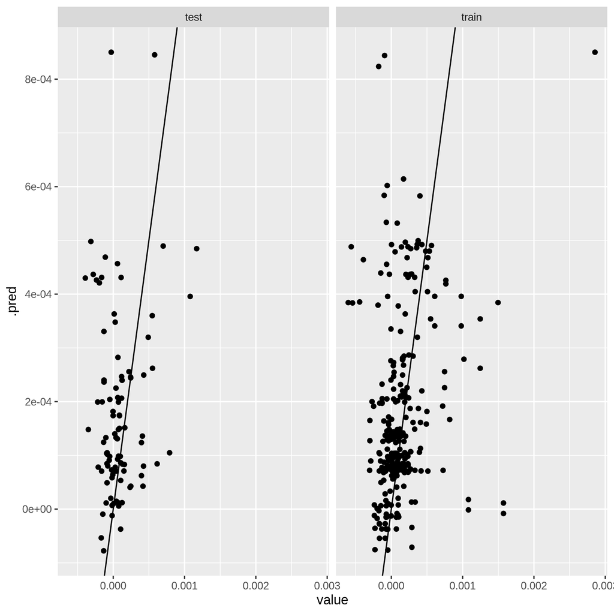

**Figure A3.4e. Model performance plot for sulfur dioxide model at the city scale.**

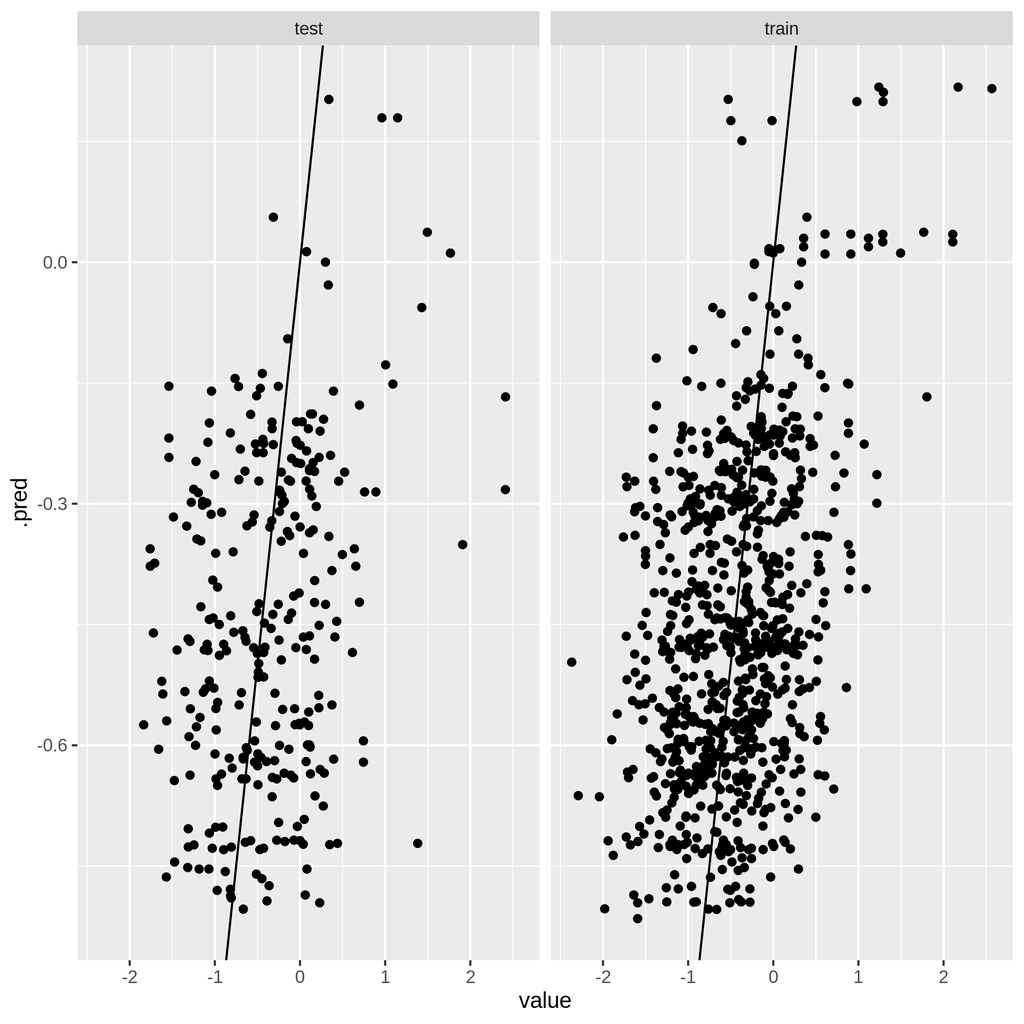

**Figure A3.4f. Model performance plot for UV aerosols model at the city scale.**

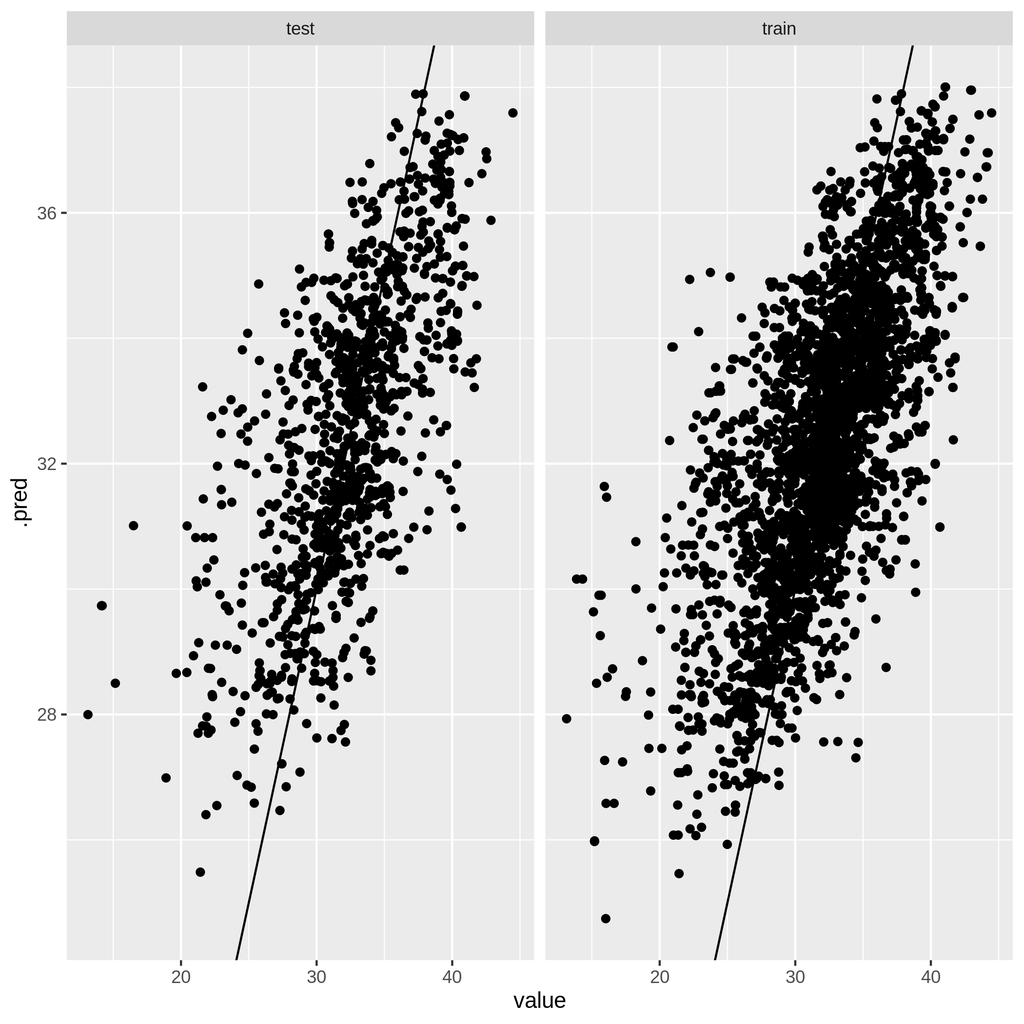

**Figure A3.4g. Model performance plot for temperature model at the neighbourhood scale.**

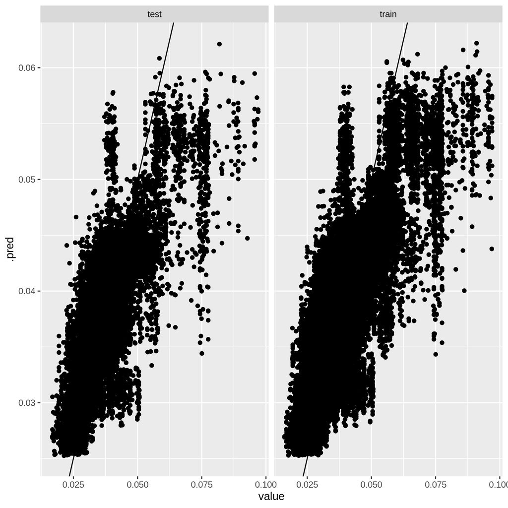

**Figure A3.4h. Model performance plot for carbon monoxide model at the neighbourhood scale.**

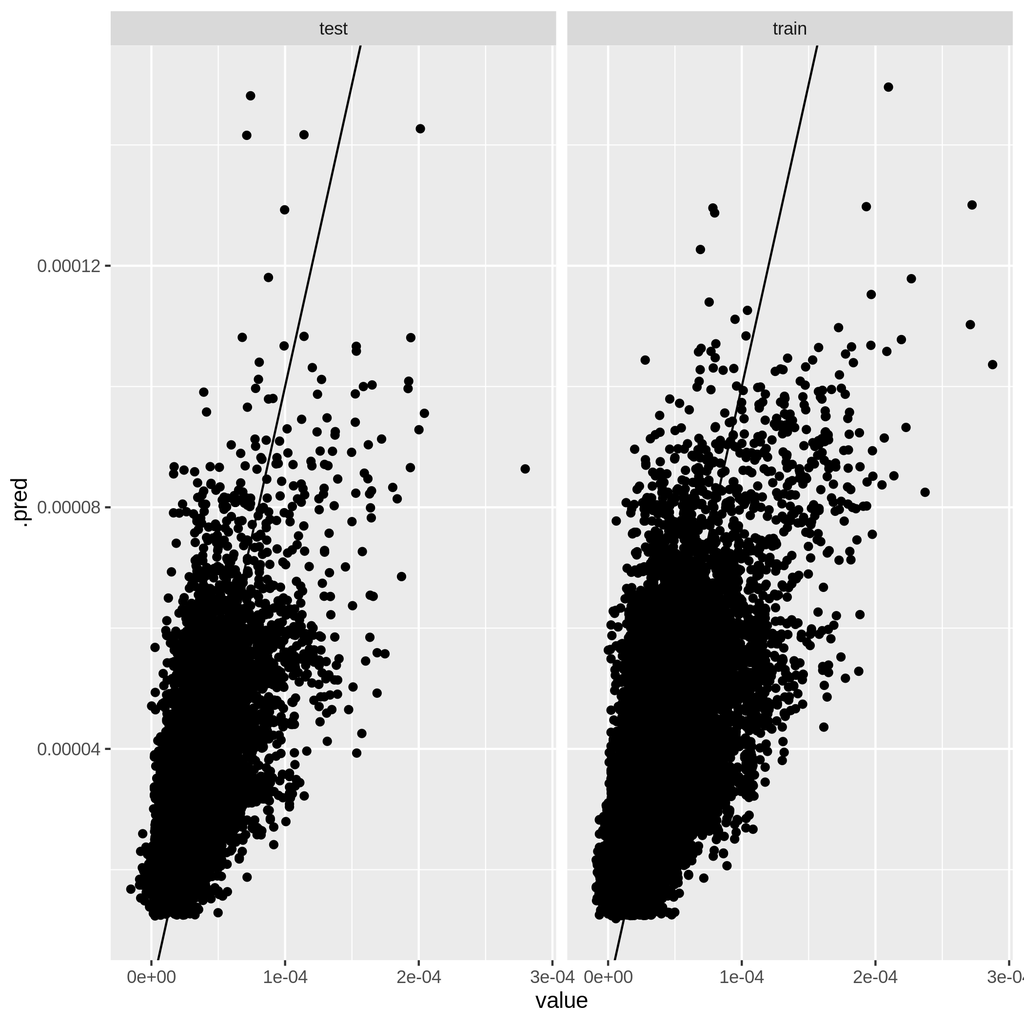

**Figure A3.4i. Model performance plot for nitrogen dioxide model at the neighbourhood scale.**